[**FMI**](http://fmi.unibuc.ro/ro/) 2019-2020

# Statistică - Laboratoare

# Proiect

Grupa 301

**Notă:** Raportul poate fi scris în *Microsoft Word* sau (pentru ușurință recomand folosirea pachetului *rmarkdown* din *R* - mai multe informații găsiți pe site la secțiunea *Link-uri utile*). Toate simulările, figurile și codurile folosite trebuie incluse în raport. Se va folosi doar limbajul *R*.

# 1 Problema 1

Un segment de lungime $1$ este rupt în trei bucăți. Presupunând că punctele de ruptură sunt date de două variabile aleatoare $X$ și $Y$ repartizate pe $[0,1]$, Scopul acestui exercțiu este să determinăm, în funcție de procedura de alegere a punctelor de ruptură, care este probabilitatea de formare a unui triunghi cu lungimile celor trei segmente obținute.

**Procedura $1$:** Presupunem că punctele de ruptură sunt date de două variabile aleatoare $X$ și $Y$, independente și repartizate uniform pe intervalul $[0,1]$.

4.[^1] Presupunând că punctele de ruptură sunt date de procedura $1$, ce puteți spune despre probabilitatea de formare a unui triunghi obtuzunghic ? Justificați atât teoretic cât și prin simulare.

Ne întrebăm acum ce se întâmplă cu probabilitatea de formare a unui triunghi cu ajutorul celor trei segmente determinate de punctele de ruptură dacă adoptăm următoarele două proceduri.

**Procedura 2:** Alegem pentru început un punct de ruptură $X$ repartizat uniform $\mathcal{U}([0,1])$ și dintre cele două segmente formate îl alegem pe cel mai lung pe care alegem un al doilea punct, $Y$, repartizat uniform pe acest segment.

**Procedura 3:** Alegem pentru început un punct de ruptură $X$ repartizat uniform $\mathcal{U}([0,1])$ care va împărții segmentul $[0,1]$ în două subsegmente. Aruncăm, de manieră independentă, o monedă echilibrată și alegem în funcție de rezultatul aruncării, cap sau pajură, segementul din stânga (cap) sau cel din dreapta (pajură). Pe segmentul selecționat alegem un al doilea punct de ruptură, $Y$, repartizat uniform pe acest segment.

# 2 Problema 2

Fie $\mathbf{X}=(X_1, X_2)$ un vector aleator din $\mathbb{R}^2$ cu densitate $f_1$ proporțională cu

$$\tilde{f}_1(x_1, x_2) = \exp \left[-\frac{1}{2}\left(\frac{x_{1}^{2}}{4}+x_{2}^{2}\right)\right] \mathbf{1}_{\left\{| x_{2} | \leq 1\right\}},$$

și $\mathbf{Y}=(Y_1, Y_2)$ un vector aleator din $\mathbb{R}^2$ cu densitate $f_2$ proporțională cu

$$\tilde{f}_2(y_1, y_2) = \left[\cos ^{2}\left(y_{1}\right)+0.5 \sin ^{2}\left(3 y_{2}\right) \cos ^{4}\left(y_{1}\right)\right] \exp \left[-\frac{1}{2}\left(\frac{y_{1}^{2}}{4}+y_{2}^{2}\right)\right].$$

Obiectivul acestei probleme este de a construi un algoritm (prin metoda respingerii) care să permită simularea de observații din repartițiile $f_1$ și respectiv $f_2$.

1. Arătați că pentru a genera o observație din repartiția $f$ putem aplica algoritmul de acceptare-respingere funcției $\tilde{f}$.
2. Determinați constantele $M_1$, $M_2$ și o densitate $g$ astfel încât pentru $\mathbf{x}=(x_1,x_2)\in\mathbb{R}^2$

$$\tilde{f}_1(\mathbf{x})\leq M_1 g(\mathbf{x}) \quad \text{și}\quad \tilde{f}_2(\mathbf{x})\leq M_2 g(\mathbf{x}).$$

3. Deduceți o metodă de simulare din repartițiile de densitate $f_1$ și $f_2$. Construiți câte o funcție în `R` care să implementeze această metodă pentru fiecare densitate în parte și generați câte un eșantion de talie $n = 100000$ din fiecare densitate bidimensională. Puteți optimiza procedura, vectoriza codul ?
4. Comparați densitățile marginale empirice rezultate din eșantionul generat anterior pentru repartiția de densitate $f_1$ cu densitățile marginale teoretice ale lui $f_1$ prin trasarea unei histograme peste care suprapunem densitatea teoritică (a se vedea figura de mai jos).

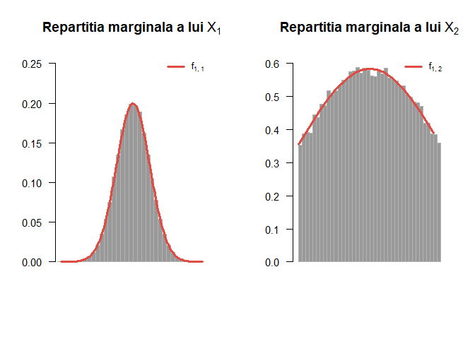

5. Comparați repartiția empirică cu cea teoretică în cazul $f_1$ printr-o reprezentare 2D/3D cu ajutorul pachetului `plot3D` (a se vedea funcțiile `hist3D`, `persp3d` și `image2D`). (a se vedea figura de mai jos)

**Indicație**: Pentru trasarea repartiției empirice (a histogramei 3d) aveți nevoie să construiți o funcție care să returneze repartiția empirică a eșantionului 2d pe un grid dat (o partiție 2d). Pentru a crea diviziunea bidimensională (echidistantă) puteți folosi funcția `cut` (pe fiecare dimensiune) iar pentru a determina câte puncte cad în fiecare subregiune dreptunghiulară puteți folosi funcția `table`. Țineți cont și de normalizarea histogramei !

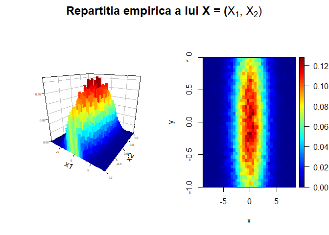

[^1]: Această întrebare este mai dificilă și nerezolvarea ei nu scade punctajul proiectului. Cu toate acestea, cine reușește să facă acest subpunct va primi 0.5 puncte suplimentare.